# What Drives Household Food Spending? A Regression Analysis

Parnika Raina

2026-01-19

## About This Project

An individual applied regression project using household expenditure data provided for a university statistics course, working from a business question through data cleaning, modelling, and interpretation to reach a conclusion.

### Business Problem

Understanding what drives a household’s weekly food spending is useful for anyone trying to model or predict household budgets. This analysis looks at household characteristics and spending patterns, and specifically asks whether the relationship between alcohol spending and food spending changes depending on how much debt a household carries. If it does, debt level would be an important segmentation factor; if it doesn’t, one model can be used across debt levels without splitting the population up.

### Data Dictionary

This data covers weekly household expenditure in England. The variables are described below.

| Variable | Description |
| --- | --- |
| Kids | Number of kids in the household |
| HouseholdSize | Number of members living in the household |
| Sex | The sex of the survey respondent (male/female) |
| Vehicles | Number of vehicles owned by the household |
| Food | Average amount spent on food per week |
| Housing | Average amount spent on accommodation per week |
| Alcohol | Average weekly spend on alcohol |
| Debt | Average weekly spend on debt repayments |
| income_category | The household’s income level (Low/Medium/High) |

### Data Overview

```r
#Reading the data
Household_data <- read_csv("HouseholdExpenditure_csv.csv")
# Summary statistics for numerical variables
Household_data %>%
  select(where(is.numeric)) %>%
  summary()
```

```
##       Kids        HouseholdSize       Vehicles          Food           Housing
##  Min.   :0.0000   Min.   : 1.000   Min.   :0.000   Min.   : 12.25   Min.   :155.9
##  1st Qu.:0.0000   1st Qu.: 1.000   1st Qu.:0.000   1st Qu.: 48.59   1st Qu.:281.8
##  Median :0.0000   Median : 2.000   Median :1.000   Median : 57.27   Median :314.1
##  Mean   :0.5849   Mean   : 2.378   Mean   :1.077   Mean   : 57.44   Mean   :319.2
##  3rd Qu.:1.0000   3rd Qu.: 3.000   3rd Qu.:2.000   3rd Qu.: 66.21   3rd Qu.:351.3
##  Max.   :8.0000   Max.   :11.000   Max.   :7.000   Max.   :103.54   Max.   :639.2
##  NA's   :6        NA's   :6
##     Alcohol            Debt
##  Min.   : 7.429   Min.   :  0.00
##  1st Qu.:14.920   1st Qu.: 49.46
##  Median :17.012   Median : 59.85
##  Mean   :17.014   Mean   : 59.97
##  3rd Qu.:19.099   3rd Qu.: 70.78
##  Max.   :27.658   Max.   :148.41
##                   NA's   :8
```

```r
glimpse(Household_data)
```

```
## Rows: 4,097
## Columns: 9
## $ Kids            <dbl> 0, 4, 2, 0, 0, 0, 3, 3, 2, 3, 2, 0, 0, 0, 0, 0, 0, 0, 0, 0, 0, 0, 0, 0, 0,…
## $ HouseholdSize   <dbl> 3, 5, 3, 2, 1, 1, 6, 5, 4, 4, 4, 1, 2, 2, 2, 2, 1, 1, 1, 1, 2, 2, 3, 1, 3,…
## $ Sex             <chr> "male", "female", "female", "male", "female", "male", "male", "male", "mal…
## $ Vehicles        <dbl> 0, 1, 2, 0, 1, 0, 1, 1, 2, 3, 1, 1, 2, 2, 1, 2, 0, 1, 1, 2, 2, 2, 1, 0, 1,…
## $ Food            <dbl> 71.916, 48.162, 61.355, 55.090, 53.758, 34.579, 70.244, 70.791, 42.568, 84…
## $ Housing         <dbl> 349.40, 288.99, 299.56, 300.69, 258.07, 261.11, 460.16, 305.78, 269.13, 28…
## $ Alcohol         <dbl> 16.659, 17.344, 18.861, 16.811, 14.131, 13.446, 15.230, 20.721, 18.642, 19…
## $ Debt            <dbl> 59.050, 76.842, 47.805, 85.109, 68.687, 32.706, 106.113, 55.882, 59.616, 6…
## $ income_category <chr> "High", "Medium", "Low", "High", "Medium", "Low", "Medium", "Medium", "Med…
```

```r
#Data integrity:-


missing_summary <- Household_data %>%
  summarise(across(everything(), ~sum(is.na(.)))) %>%
  pivot_longer(everything(), names_to = "Variable", values_to = "Missing_Count")

print(missing_summary)
```

```
## # A tibble: 9 × 2
##   Variable        Missing_Count
##   <chr>                   <int>
## 1 Kids                        6
## 2 HouseholdSize               6
## 3 Sex                         6
## 4 Vehicles                    0
## 5 Food                        0
## 6 Housing                     0
## 7 Alcohol                     0
## 8 Debt                        8
## 9 income_category             6
```

```r
cat("Number of duplicate rows:", sum(duplicated(Household_data)), "\n")
```

```
## Number of duplicate rows: 0
```

A few variables have a handful of missing values, there are no duplicate households, and the figures all look realistic - so filtering out the missing values is the only cleaning needed before moving on.

### Filtering the data

```r
cat("Rows before filtering:", nrow(Household_data), "\n\n")
```

```
## Rows before filtering: 4097
```

```r
# Removing the missing data in key variables
household_filtered <- Household_data %>%
  filter(!is.na(Food),
         !is.na(Alcohol),
         !is.na(Debt),
         !is.na(Vehicles),
         !is.na(Kids),
         !is.na(Housing),
         !is.na(HouseholdSize),
         !is.na(Sex),
         !is.na(income_category))
```

```r
# Converting categorical variables to factors

household_filtered <- household_filtered %>%
  mutate(
    Sex = factor(Sex),
    income_category = factor(income_category,
                            levels = c("Low", "Medium", "High"),
                            ordered = FALSE)
  )

cat("Rows after filtering:", nrow(household_filtered), "\n")
```

```
## Rows after filtering: 4083
```

```r
cat("Percentage of data retained:",
    round(100 * nrow(household_filtered) / nrow(Household_data), 1), "%\n\n")
```

```
## Percentage of data retained: 99.7 %
```

```r
summary(household_filtered)
```

```
##       Kids        HouseholdSize        Sex          Vehicles          Food           Housing
##  Min.   :0.0000   Min.   : 1.000   female:1572   Min.   :0.000   Min.   : 12.25   Min.   :155.9
##  1st Qu.:0.0000   1st Qu.: 1.000   male  :2511   1st Qu.:0.000   1st Qu.: 48.60   1st Qu.:281.8
##  Median :0.0000   Median : 2.000                 Median :1.000   Median : 57.30   Median :314.1
##  Mean   :0.5851   Mean   : 2.379                 Mean   :1.076   Mean   : 57.46   Mean   :319.3
##  3rd Qu.:1.0000   3rd Qu.: 3.000                 3rd Qu.:2.000   3rd Qu.: 66.20   3rd Qu.:351.4
##  Max.   :8.0000   Max.   :11.000                 Max.   :7.000   Max.   :103.54   Max.   :639.2
##     Alcohol            Debt        income_category
##  Min.   : 7.429   Min.   :  0.00   Low   :1102
##  1st Qu.:14.921   1st Qu.: 49.47   Medium:2531
##  Median :17.015   Median : 59.88   High  : 450
##  Mean   :17.018   Mean   : 59.98
##  3rd Qu.:19.099   3rd Qu.: 70.81
##  Max.   :27.658   Max.   :148.41
```

Almost every household was retained after filtering, so very little information was lost and the data is still representative. Categorical variables were converted to factors before modelling, so R treats them as groups rather than as numbers.

### Demonstrating the Distribution of the Relevant Variables

### Food Distribution

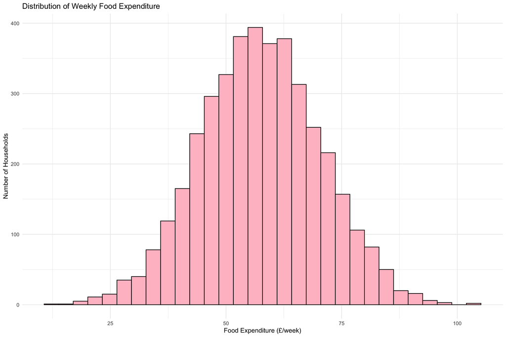

```r
  ggplot(household_filtered, aes(x = Food)) +
  geom_histogram(bins = 30, fill = "pink", colour = "black" ) +
  labs(title = "Distribution of Weekly Food Expenditure",
        x = "Food Expenditure (£/week)", y = "Number of Households") +
  theme_minimal()
```

### Debt Distribution

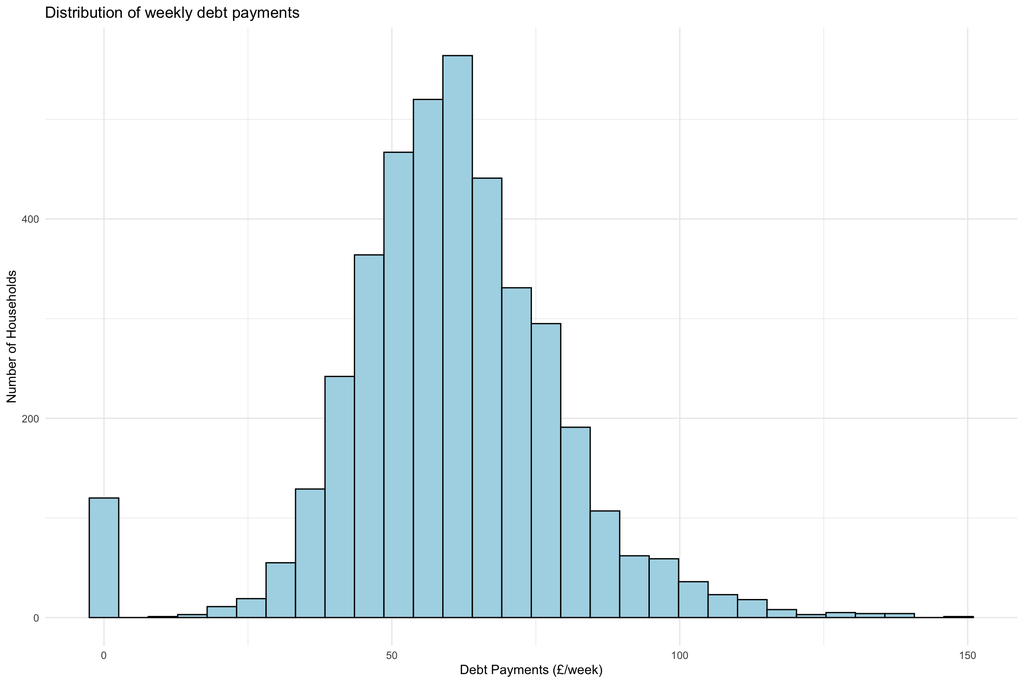

```r
  ggplot(household_filtered, aes(x = Debt)) +
  geom_histogram(bins = 30, fill = "lightblue", colour = "black") +
  labs( title = "Distribution of weekly debt payments", x = "Debt Payments (£/week)", y = "Number of Households") +
  theme_minimal()
```

Debt payments are less evenly spread - most households pay between £40 and £70 a week, with fewer at the very low or very high end. Because debt isn’t evenly distributed, it makes sense to check whether households at different debt levels show a different relationship between alcohol and food spending.

### Alcohol Distribution

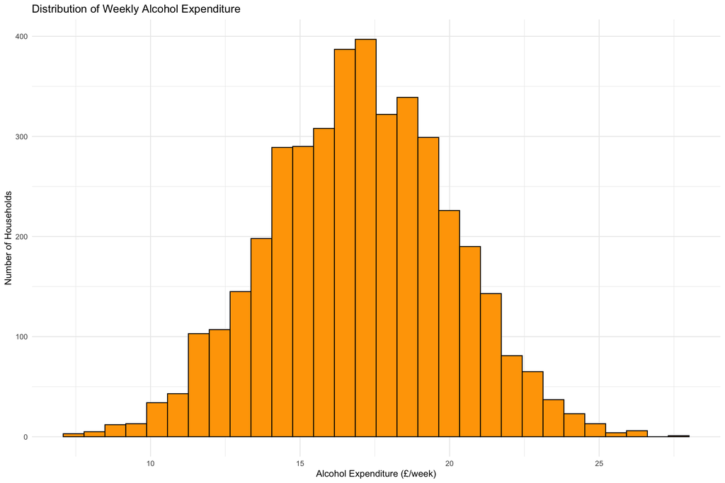

```r
  ggplot(household_filtered, aes(x = Alcohol)) +
  geom_histogram(bins = 30, fill = "orange", colour = "black") +
  labs( title =  "Distribution of Weekly Alcohol Expenditure", x = "Alcohol Expenditure (£/week)", y = "Number of Households") +
  theme_minimal()
```

The average household spends between £15 and £20 a week on alcohol, with relatively few spending a lot more or a lot less.

### Demonstrating the Relationships of the Relevant Variables

### Food vs Housing

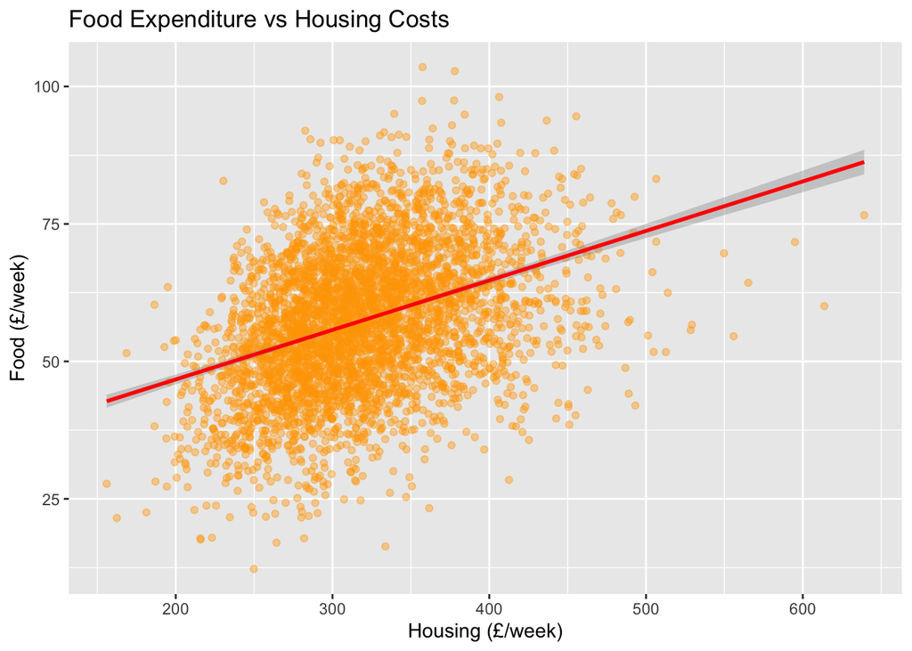

```r
ggplot(household_filtered, aes(x = Housing, y = Food)) +
  geom_point(alpha = 0.4, color = "orange") +
  geom_smooth(method = "lm", color = "red") +
  labs( title= "Food Expenditure vs Housing Costs", x = "Housing (£/week)", y = "Food (£/week)")
```

Food spending tends to rise a little as housing costs rise, though the relationship is fairly loose - useful as a control variable in a model, but not a strong predictor of food spending on its own.

### Alcohol vs Food

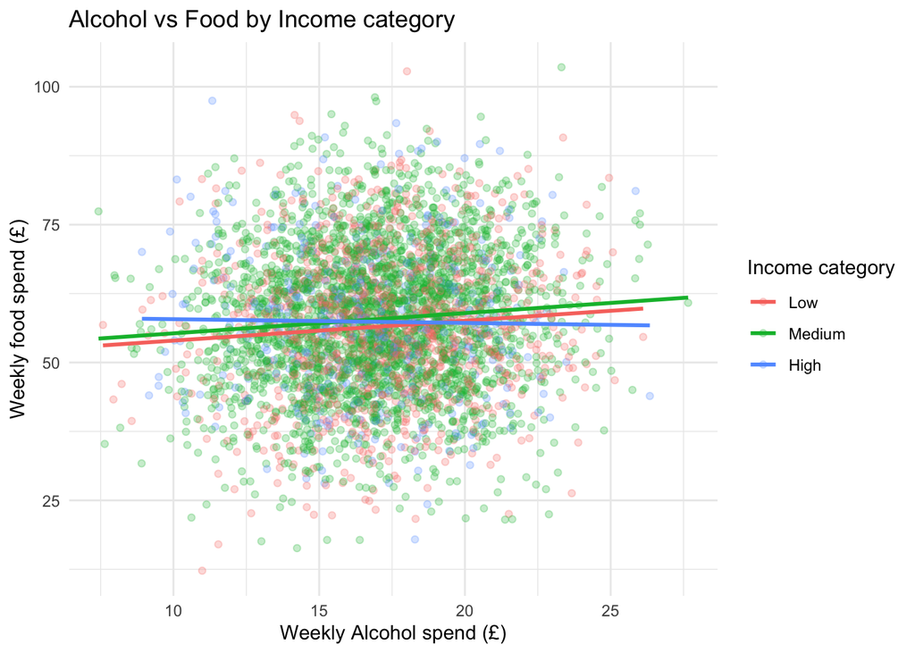

```r
ggplot(household_filtered, aes(x = Alcohol, y = Food, colour = income_category)) +
geom_point(alpha = 0.25) +
geom_smooth(method = "lm", se = FALSE) +
theme_minimal() +
labs(title = "Alcohol vs Food by Income category",
    x = "Weekly Alcohol spend (£)", y = "Weekly food spend (£)",
    colour = "Income category")
```

### Food vs Debt

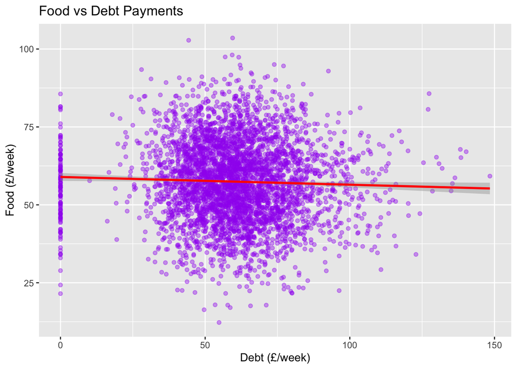

```r
ggplot(household_filtered, aes(x = Debt, y = Food)) +
  geom_point(alpha = 0.4, color = "purple") +
  geom_smooth(method = "lm", color = "red") +
  labs( title = "Food vs Debt Payments", x = "Debt (£/week)", y = "Food (£/week)")
```

Debt on its own has only a weak relationship with food spending, which suggests food spending isn’t something debt alone can explain - a good reason to build a model that accounts for several household factors at once rather than looking at any one variable in isolation.

### Food vs Alcohol Across Debt Bands

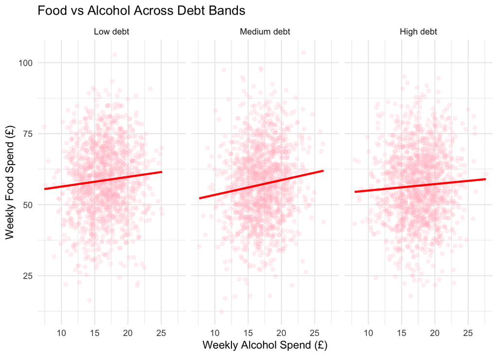

```r
household_filtered %>%
  mutate(
    DebtBand = cut(
      Debt,
      breaks = quantile(Debt, probs = c(0, 0.33, 0.66, 1), na.rm = TRUE),
      labels = c("Low debt", "Medium debt", "High debt"),
      include.lowest = TRUE
    )
  ) %>%
  ggplot() +
  geom_point(
    aes(Alcohol, Food),
    alpha = 0.2,
    colour = "pink"
  ) +
  geom_smooth(
    aes(Alcohol, Food),
    method = "lm",
    se = FALSE,
    colour = "red"
  ) +
  facet_wrap(~ DebtBand) +
  labs(
    title = "Food vs Alcohol Across Debt Bands",
    x = "Weekly Alcohol Spend (£)",
    y = "Weekly Food Spend (£)"
  ) +
  theme_minimal()
```

Households at low, medium, and high debt levels all show a similar pattern: food spending rises somewhat as alcohol spending rises. At a glance, debt doesn’t look like it’s changing that relationship - worth checking formally with a model.

### Model 1

```r
m.food <- lm(Food ~ HouseholdSize + Sex + Vehicles + Housing + Kids +
               Alcohol + Debt + income_category, data = household_filtered)

summary(m.food)
```

```
##
## Call:
## lm(formula = Food ~ HouseholdSize + Sex + Vehicles + Housing +
##     Kids + Alcohol + Debt + income_category, data = household_filtered)
##
## Residuals:
##     Min      1Q  Median      3Q     Max
## -42.300  -8.124  -0.090   8.081  39.699
##
## Coefficients:
##                        Estimate Std. Error t value Pr(>|t|)
## (Intercept)           23.472590   1.688695  13.900  < 2e-16 ***
## HouseholdSize          0.175645   0.291747   0.602   0.5472
## Sexmale               -0.083423   0.405226  -0.206   0.8369
## Vehicles               0.360337   0.216622   1.663   0.0963 .
## Housing                0.091439   0.003485  26.241  < 2e-16 ***
## Kids                  -0.412563   0.354191  -1.165   0.2442
## Alcohol                0.388444   0.062415   6.224 5.35e-10 ***
## Debt                  -0.049175   0.009718  -5.060 4.38e-07 ***
## income_categoryMedium  0.928248   0.477733   1.943   0.0521 .
## income_categoryHigh    0.392923   0.749619   0.524   0.6002
## ---
## Signif. codes:  0 '***' 0.001 '**' 0.01 '*' 0.05 '.' 0.1 ' ' 1
##
## Residual standard error: 11.91 on 4073 degrees of freedom
## Multiple R-squared:  0.1536, Adjusted R-squared:  0.1517
## F-statistic:  82.1 on 9 and 4073 DF,  p-value: < 2.2e-16
```

```r
cbind(coef(m.food), confint(m.food))
```

```
##                                          2.5 %      97.5 %
## (Intercept)           23.47258986 20.161823787 26.78335593
## HouseholdSize          0.17564548 -0.396338881  0.74762984
## Sexmale               -0.08342262 -0.877887408  0.71104218
## Vehicles               0.36033683 -0.064361166  0.78503482
## Housing                0.09143859  0.084606809  0.09827037
## Kids                  -0.41256305 -1.106971175  0.28184507
## Alcohol                0.38844391  0.266075449  0.51081238
## Debt                  -0.04917521 -0.068228709 -0.03012171
## income_categoryMedium  0.92824782 -0.008370389  1.86486603
## income_categoryHigh    0.39292268 -1.076740484  1.86258585
```

This model looks at weekly food spending against household characteristics and other spending, all together. It’s statistically significant overall, meaning these variables jointly help explain food spending.

The model explains about 15% of the variation in food spending - a modest amount, but reasonable for household survey data where a lot of what drives someone’s spending simply isn’t captured here.

Housing and alcohol spending are the strongest predictors: households that spend more on either tend to spend more on food too, while higher debt is linked to slightly lower food spending. Household size, number of children, sex, and income category don’t show a significant effect once spending patterns are accounted for, and vehicle ownership’s relationship is weak and unclear.

### Model 2

```r
m.interaction <- lm(
  Food ~ HouseholdSize + Kids + Vehicles + Housing +
    income_category + Sex + Alcohol * Debt,
  data = household_filtered
)

summary(m.interaction)
```

```
##
## Call:
## lm(formula = Food ~ HouseholdSize + Kids + Vehicles + Housing +
##     income_category + Sex + Alcohol * Debt, data = household_filtered)
##
## Residuals:
##     Min      1Q  Median      3Q     Max
## -42.266  -8.132  -0.073   8.076  39.685
##
## Coefficients:
##                        Estimate Std. Error t value Pr(>|t|)
## (Intercept)           21.915513   3.553285   6.168  7.6e-10 ***
## HouseholdSize          0.175203   0.291776   0.600   0.5482
## Kids                  -0.413691   0.354231  -1.168   0.2429
## Vehicles               0.358828   0.216663   1.656   0.0978 .
## Housing                0.091406   0.003486  26.224  < 2e-16 ***
## income_categoryMedium  0.929349   0.477782   1.945   0.0518 .
## income_categoryHigh    0.398080   0.749760   0.531   0.5955
## Sexmale               -0.086225   0.405303  -0.213   0.8315
## Alcohol                0.481121   0.196267   2.451   0.0143 *
## Debt                  -0.022715   0.054008  -0.421   0.6741
## Alcohol:Debt          -0.001549   0.003110  -0.498   0.6185
## ---
## Signif. codes:  0 '***' 0.001 '**' 0.01 '*' 0.05 '.' 0.1 ' ' 1
##
## Residual standard error: 11.92 on 4072 degrees of freedom
## Multiple R-squared:  0.1536, Adjusted R-squared:  0.1515
## F-statistic:  73.9 on 10 and 4072 DF,  p-value: < 2.2e-16
```

```r
confint(m.interaction)
```

```
##                              2.5 %       97.5 %
## (Intercept)           14.949131847 28.881893918
## HouseholdSize         -0.396836589  0.747243120
## Kids                  -1.108177360  0.280795586
## Vehicles              -0.065950708  0.783606795
## Housing                0.084572459  0.098239679
## income_categoryMedium -0.007365523  1.866064042
## income_categoryHigh   -1.071858860  1.868019463
## Sexmale               -0.880839790  0.708389751
## Alcohol                0.096330125  0.865912496
## Debt                  -0.128599782  0.083169216
## Alcohol:Debt          -0.007646147  0.004548258
```

This model tests directly whether the relationship between alcohol and food spending changes at different debt levels, by adding an alcohol-by-debt interaction term. It’s statistically significant overall.

Alcohol spending still has a positive relationship with food spending, and housing remains the strongest predictor. But the interaction between alcohol and debt itself isn’t statistically significant - meaning debt doesn’t meaningfully change how alcohol relates to food spending. As before, household size, number of children, sex, and income category don’t show a significant effect once spending is accounted for.

### Anova Test

```r
anova(m.food, m.interaction)
```

```
## Analysis of Variance Table
##
## Model 1: Food ~ HouseholdSize + Sex + Vehicles + Housing + Kids + Alcohol +
##     Debt + income_category
## Model 2: Food ~ HouseholdSize + Kids + Vehicles + Housing + income_category +
##     Sex + Alcohol * Debt
##   Res.Df    RSS Df Sum of Sq      F Pr(>F)
## 1   4073 578186
## 2   4072 578150  1    35.221 0.2481 0.6185
```

Adding the alcohol-debt interaction doesn’t improve the model in a statistically meaningful way. This confirms the simpler model without the interaction is enough: alcohol’s relationship with food spending doesn’t really depend on a household’s debt level.

### Emmeans

```r
emmeans(
  m.interaction,
  specs = ~ Alcohol | Debt,
  at = list(
    Alcohol = c(10, 15, 20),
    Debt = quantile(household_filtered$Debt, c(.25,.50,.75))
  )
)
```

```
## Debt = 49.5:
##  Alcohol emmean    SE   df lower.CL upper.CL
##       10   55.0 0.537 4072     53.9     56.0
##       15   57.0 0.288 4072     56.4     57.6
##       20   59.0 0.353 4072     58.3     59.7
##
## Debt = 59.9:
##  Alcohol emmean    SE   df lower.CL upper.CL
##       10   54.6 0.498 4072     53.6     55.6
##       15   56.5 0.272 4072     56.0     57.1
##       20   58.5 0.307 4072     57.9     59.1
##
## Debt = 70.8:
##  Alcohol emmean    SE   df lower.CL upper.CL
##       10   54.2 0.584 4072     53.0     55.3
##       15   56.0 0.310 4072     55.4     56.6
##       20   57.9 0.322 4072     57.2     58.5
##
## Results are averaged over the levels of: income_category, Sex
## Confidence level used: 0.95
```

Predicted food spending rises as alcohol spending rises, at every debt level. The size of that increase is similar whether debt is low, medium, or high - consistent with the ANOVA result above, confirming debt doesn’t meaningfully change the alcohol-food relationship, even though households with higher debt do tend to spend a little less on food overall.

### Conclusion

Food spending rises as alcohol spending rises, and this relationship holds fairly consistently across low, medium, and high debt households - the interaction between alcohol and debt was not statistically significant. Housing and alcohol spending are the two strongest predictors of food spending overall, while household size, number of children, sex, and income category don’t add much once spending patterns are accounted for. For anyone modelling household food spending, this suggests debt level doesn’t need to be treated as a special segmentation factor for the alcohol relationship specifically, though it’s still a useful control variable in its own right.